# Zadanie R Markdown

Agnieszka

Sunday, May 24, 2015

# Regresja liniowa

Model regresji możemy zapisać następująco

$Y=\beta X+ \epsilon$

Natomiast estymator KMNK **$\beta$** określony jest następująco $\hat{\beta}=(X^TX)^{-1}X^TY$

# Dane do regresji

Użyjemy danych ze zbioru `cars` i zbudujemy model regresji `dist ~ speed`. Dodatkowo, losowo (wykorzystując funkcję `sample` wybierzemy jedynie 20 obserwacji aby dokument był czytelny.

```r
car_sub <- cars[sample(1:50,20),]
```

Macierz $X$ wygląda następująco

$\mathbf{X} = \begin{bmatrix} 1 & 25 \\ 1 & 14 \\ 1 & 13 \\ 1 & 18 \\ 1 & 20 \\ 1 & 20 \\ 1 & 18 \\ 1 & 13 \\ 1 & 12 \\ 1 & 14 \\ 1 & 19 \\ 1 & 13 \\ 1 & 24 \\ 1 & 19 \\ 1 & 9 \\ 1 & 16 \\ 1 & 24 \\ 1 & 14 \\ 1 & 10 \\ 1 & 17 \\ \end{bmatrix}$

W związku z tym $\hat{\beta}$ ma następującą postać $(X^TX)^{-1}X^TY=(\begin{bmatrix} 1 & 25 \\ 1 & 14 \\ 1 & 13 \\ 1 & 18 \\ 1 & 20 \\ 1 & 20 \\ 1 & 18 \\ 1 & 13 \\ 1 & 12 \\ 1 & 14 \\ 1 & 19 \\ 1 & 13 \\ 1 & 24 \\ 1 & 19 \\ 1 & 9 \\ 1 & 16 \\ 1 & 24 \\ 1 & 14 \\ 1 & 10 \\ 1 & 17 \\ \end{bmatrix}^T\begin{bmatrix} 1 & 25 \\ 1 & 14 \\ 1 & 13 \\ 1 & 18 \\ 1 & 20 \\ 1 & 20 \\ 1 & 18 \\ 1 & 13 \\ 1 & 12 \\ 1 & 14 \\ 1 & 19 \\ 1 & 13 \\ 1 & 24 \\ 1 & 19 \\ 1 & 9 \\ 1 & 16 \\ 1 & 24 \\ 1 & 14 \\ 1 & 10 \\ 1 & 17 \\ \end{bmatrix})^{-1}\begin{bmatrix} 1 & 25 \\ 1 & 14 \\ 1 & 13 \\ 1 & 18 \\ 1 & 20 \\ 1 & 20 \\ 1 & 18 \\ 1 & 13 \\ 1 & 12 \\ 1 & 14 \\ 1 & 19 \\ 1 & 13 \\ 1 & 24 \\ 1 & 19 \\ 1 & 9 \\ 1 & 16 \\ 1 & 24 \\ 1 & 14 \\ 1 & 10 \\ 1 & 17 \\ \end{bmatrix}^T\begin{bmatrix} 85 \\ 60 \\ 26 \\ 56 \\ 64 \\ 52 \\ 84 \\ 34 \\ 14 \\ 26 \\ 36 \\ 46 \\ 93 \\ 68 \\ 10 \\ 40 \\ 120 \\ 80 \\ 34 \\ 32 \\ \end{bmatrix}$

Co daje nam $\hat{\beta}= (X^{T}X)^{-1}X^{T}Y = (\begin{bmatrix} 20 & 332 \\ 332 & 5912 \\ \end{bmatrix})^{-1}\begin{bmatrix} 1060 \\ 19537 \\ \end{bmatrix}=\begin{bmatrix} -27.3907185628742 \\ 4.84281437125748 \\ \end{bmatrix}$

# Rysujemy wykres regresji

Wykres przedstawia zależnośc między `dist` a `speed` oraz oszacowaną krzywą regresji. Należy użyć funkcji `plot` oraz `abline`.

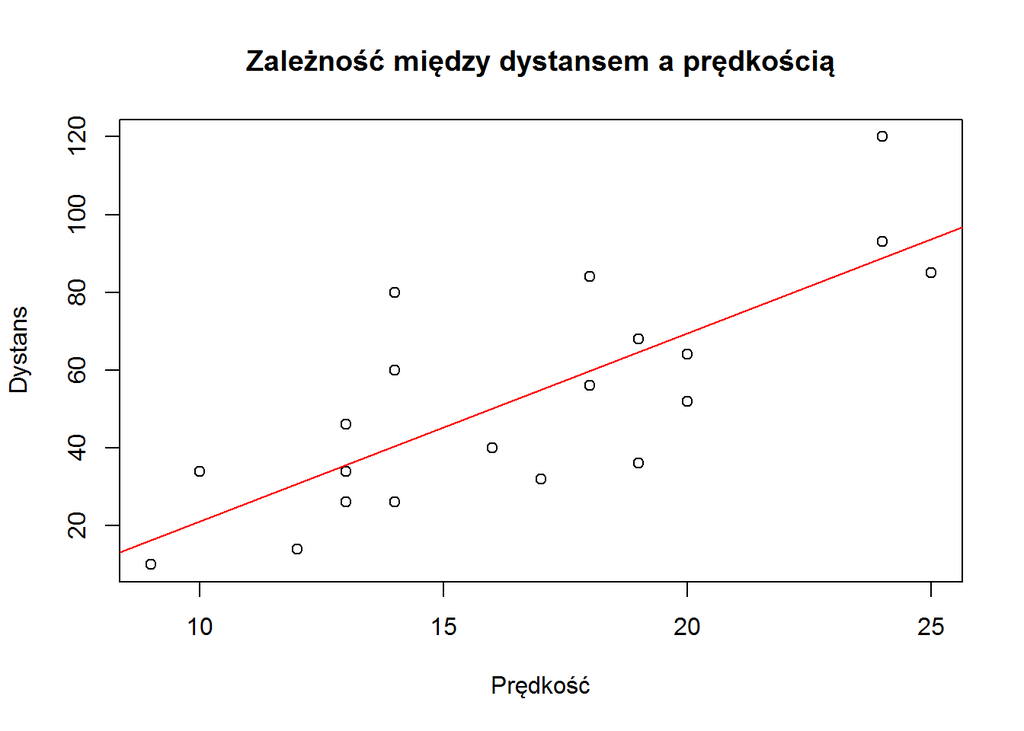